# R Fundamentals Part3-3: visualization

D-Lab

March 31, 2019 (updated 2019-03-31)

# Data visualization

Visualizing data is one of the most sought after skills in the 21st Century. R offers a variety of base plotting functions and many other packages for creating stunning visualizations.

Let’s start with “base” plotting functions (functions that are builtin to R and do not require any other installations).

## Histogram

Histograms are a handy way to illustrate the distribution shape of one numeric/integer variable. Let’s visualize the “lifeExp” variable from `gap`:

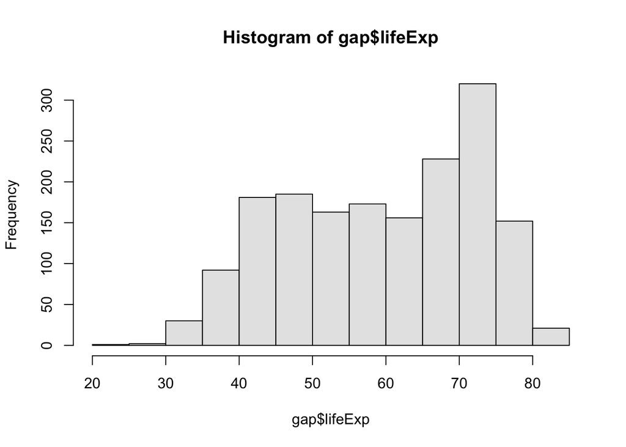

```r
gap = read.csv("/Users/evan.admin/Desktop/R-Fundamentals/inbound/gapminder-FiveYearData.csv")

hist(gap$lifeExp,
     col = "gray90")
```

The `col =` argument specifies the color of the bars. Look at the colors you can choose from in base R using `colors()`

```r
colors()
```

Some basic arguments you will want to make note of include:  
-`main` - change plot title  
-`xlab` - change x-axis label  
-`ylab` - change y-axis label  
-`las` - change orientation of the tick mark text  
- `xlim` - change the limits of the x-axis  
- `ylim` - change the limits of the y-axis

Let’s try again, this time with more arguments!

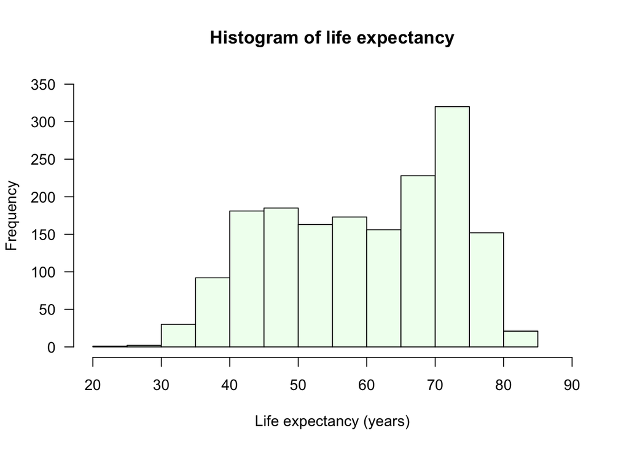

```r
hist(gap$lifeExp,
     col = "honeydew1",
     main = "Histogram of life expectancy",
     xlab = "Life expectancy (years)",
     ylab = "Frequency",
     xlim = c(20, 90),
     ylim = c(0, 350),
     las = 1)
```

Click the “Zoom” button to pop-out the plot into its own window. Click “Export” to save it as an image or .pdf file!

# **Challenge 2**

1. Create a histogram of one of the numeric variables from the `iris` dataset.

```r
## YOUR CODE HERE
```

## Boxplots

Boxplots are useful because you can graphically represent a numeric variable by levels of a factor - this requires slightly different syntax. These default to [Tukey boxplots](http://mathworld.wolfram.com/Box-and-WhiskerPlot.html).

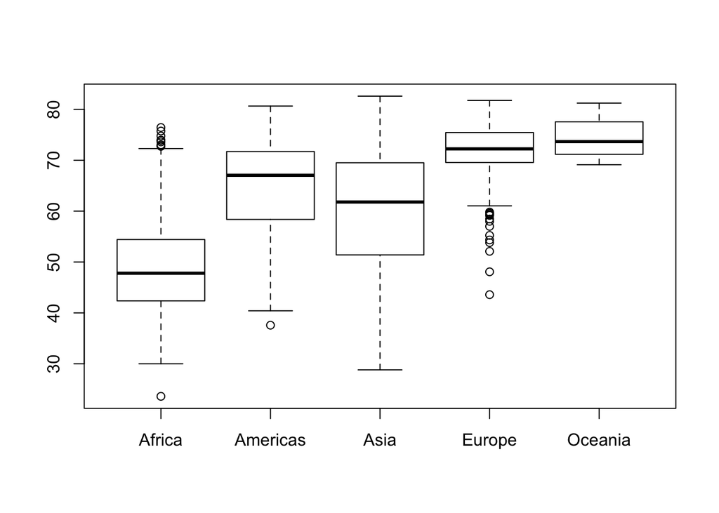

```r
boxplot(gap$lifeExp ~ gap$continent)
```

The tilde `~` means “by” some category (in our case lifeExp as parsed *by* the continents Africa, Americas, Asia, Europe, and Oceania). It simply means we want to display lifeExp by continent.

Remember your six number summary from earlier (Part3-2_data summarization)? A Tukey boxplot represents a 5 number summary (minus the mean).

Our other base plotting arguments work here as well, except we must pass in a vector of colors - one for each box.

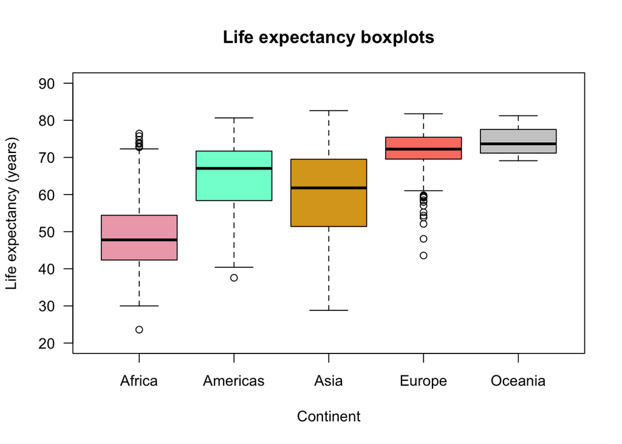

```r
boxplot(gap$lifeExp ~ gap$continent,
        col = c("pink2", "aquamarine", "goldenrod", "salmon", "gray80"),
        main = "Life expectancy boxplots",
        xlab = "Continent",
        ylab = "Life expectancy (years)",
        ylim = c(20, 90),
        las = 1)
```

```r
#That looks better!
```

# **Challenge 3**

1. Create boxplots for one of the numeric variables in the `iris` dataset as parsed by Species.

```r
## YOUR CODE HERE
```

> A note about exporting publication ready figures: R makes it easy to create pubication ready figures. However, it is not as straightforward as one might hope. For example, to produce a 6 x 6 inch 600 dpi color image, it might not be best to directly export to .TIFF. Instead, you probably want to first export this image to a .PDF first to maintain resolution, **and then** save this image to .TIFF, perhaps with some sort of file compression. This will maintain the quality of the image but will dramatically reduce the file size.

## Scatterplots

What if we want to know more about the relationships between two numeric or integer variables? Base R’s `plot()` can be useful for quick scatterplots.

Identify two numeric/integer variables you want to plot on the x and y axes:

```r
x = gap$lifeExp
y = gap$gdpPercap
```

Now, we can plot lifeExp and gdpPercap

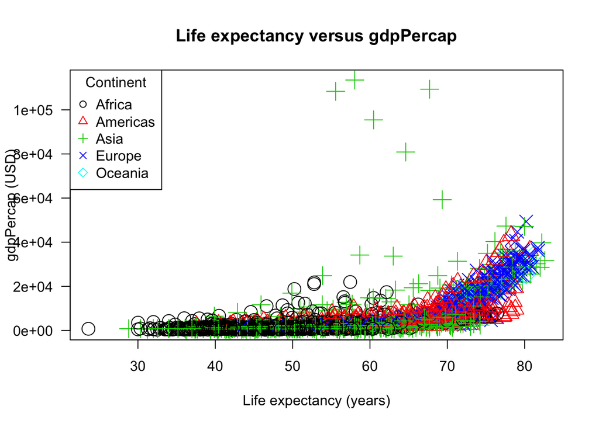

```r
plot(x = x, y = y,
    main = "Life expectancy versus gdpPercap",
    xlab = "Life expectancy (years)",
    ylab = "gdpPercap (USD)",

    # Change point colors to correspond to continents
    col = as.integer(gap$continent),

    # Change point symbols to correspond to continents
    pch = as.integer(gap$continent),

    # Change point size
    cex = 2,

    las = 1)

# This looks a little bit better, but we still do not even have a legend!

legend("topleft", inset = 0, title = "Continent", cex = 1,
       c("Africa", "Americas", "Asia", "Europe", "Oceania"), col = c(1,2,3,4,5), pch = c(1,2,3,4,5),
       horiz = FALSE)
```

There is extensive help available for finding help with colors and point shapes in R. See [here](https://www.stat.ubc.ca/~jenny/STAT545A/block14_colors.html), [here](https://www.stat.ubc.ca/~jenny/STAT545A/block15_colorMappingBase.html), and [here](http://www.sthda.com/english/wiki/r-plot-pch-symbols-the-different-point-shapes-available-in-r).

> NOTE: One drawback of R Studio is that its in-environment graphics look a little strange sometimes. However, export it and see how it looks once you adjust the size settings.

# **Challenge 4**

1. Using the `iris` dataset, plot two numeric variables in a scatterplot.

```r
## YOUR CODE HERE
```